# Reproducible Research - Course Project 2

# Health and Economic Consequences of Weather Events in United States

# Synopsis

The report addresses questions regarding the most hurtful weather type events in terms of deaths, injuries, property and crop damage

# Data Processing

### Load needed packages

[output not shown]

[output cut: 23 more lines]

```
## # A tibble: 6 x 37
##   STATE__ BGN_DATE BGN_TIME TIME_ZONE COUNTY COUNTYNAME STATE EVTYPE
##     <dbl> <fct>    <fct>    <fct>      <dbl> <fct>      <fct> <fct>
## 1       1 4/18/19… 0130     CST           97 MOBILE     AL    TORNA…
## 2       1 4/18/19… 0145     CST            3 BALDWIN    AL    TORNA…
## 3       1 2/20/19… 1600     CST           57 FAYETTE    AL    TORNA…
## 4       1 6/8/195… 0900     CST           89 MADISON    AL    TORNA…
## 5       1 11/15/1… 1500     CST           43 CULLMAN    AL    TORNA…
## 6       1 11/15/1… 2000     CST           77 LAUDERDALE AL    TORNA…
## # ... with 29 more variables: BGN_RANGE <dbl>, BGN_AZI <fct>,
## #   BGN_LOCATI <fct>, END_DATE <fct>, END_TIME <fct>, COUNTY_END <dbl>,
## #   COUNTYENDN <lgl>, END_RANGE <dbl>, END_AZI <fct>, END_LOCATI <fct>,
## #   LENGTH <dbl>, WIDTH <dbl>, F <int>, MAG <dbl>, FATALITIES <dbl>,
## #   INJURIES <dbl>, PROPDMG <dbl>, PROPDMGEXP <fct>, CROPDMG <dbl>,
## #   CROPDMGEXP <fct>, WFO <fct>, STATEOFFIC <fct>, ZONENAMES <fct>,
## #   LATITUDE <dbl>, LONGITUDE <dbl>, LATITUDE_E <dbl>, LONGITUDE_ <dbl>,
## #   REMARKS <fct>, REFNUM <dbl>
```

## Questions

### 1. Across the United States, which types of events (as indicated in the EVTYPE variable) are most harmful with respect to population health?

```r
# Subset the data using only the values needed
var2use<-c("EVTYPE", "FATALITIES", "INJURIES", "PROPDMG", "PROPDMGEXP", "CROPDMG", "CROPDMGEXP")
storm<-storm[var2use]
str(storm)
```

```
## 'data.frame':    902297 obs. of  7 variables:
##  $ EVTYPE    : Factor w/ 985 levels "   HIGH SURF ADVISORY",..: 834 834 834 834 834 834 834 834 834 834 ...
##  $ FATALITIES: num  0 0 0 0 0 0 0 0 1 0 ...
##  $ INJURIES  : num  15 0 2 2 2 6 1 0 14 0 ...
##  $ PROPDMG   : num  25 2.5 25 2.5 2.5 2.5 2.5 2.5 25 25 ...
##  $ PROPDMGEXP: Factor w/ 19 levels "","-","?","+",..: 17 17 17 17 17 17 17 17 17 17 ...
##  $ CROPDMG   : num  0 0 0 0 0 0 0 0 0 0 ...
##  $ CROPDMGEXP: Factor w/ 9 levels "","?","0","2",..: 1 1 1 1 1 1 1 1 1 1 ...
```

```r
head(tbl_df(storm))
```

```
## # A tibble: 6 x 7
##   EVTYPE  FATALITIES INJURIES PROPDMG PROPDMGEXP CROPDMG CROPDMGEXP
##   <fct>        <dbl>    <dbl>   <dbl> <fct>        <dbl> <fct>
## 1 TORNADO          0       15    25   K                0 ""
## 2 TORNADO          0        0     2.5 K                0 ""
## 3 TORNADO          0        2    25   K                0 ""
## 4 TORNADO          0        2     2.5 K                0 ""
## 5 TORNADO          0        2     2.5 K                0 ""
## 6 TORNADO          0        6     2.5 K                0 ""
```

```r
# For this question I am going to find which EVTYPE leads to more FATALITES and INJURIES and present the 10 most dominant ones
total_deaths<-aggregate(FATALITIES ~ EVTYPE, data=storm, FUN = sum)

total_injuries<-aggregate(INJURIES ~ EVTYPE, data=storm, FUN = sum)

total_deaths_sorted<- total_deaths %>% arrange(-total_deaths$FATALITIES)

total_injuries_sorted<- total_injuries %>% arrange(-total_injuries$INJURIES)

most_fatal_events<-head(total_deaths_sorted,10)
most_fatal_events
```

```
##            EVTYPE FATALITIES
## 1         TORNADO       5633
## 2  EXCESSIVE HEAT       1903
## 3     FLASH FLOOD        978
## 4            HEAT        937
## 5       LIGHTNING        816
## 6       TSTM WIND        504
## 7           FLOOD        470
## 8     RIP CURRENT        368
## 9       HIGH WIND        248
## 10      AVALANCHE        224
```

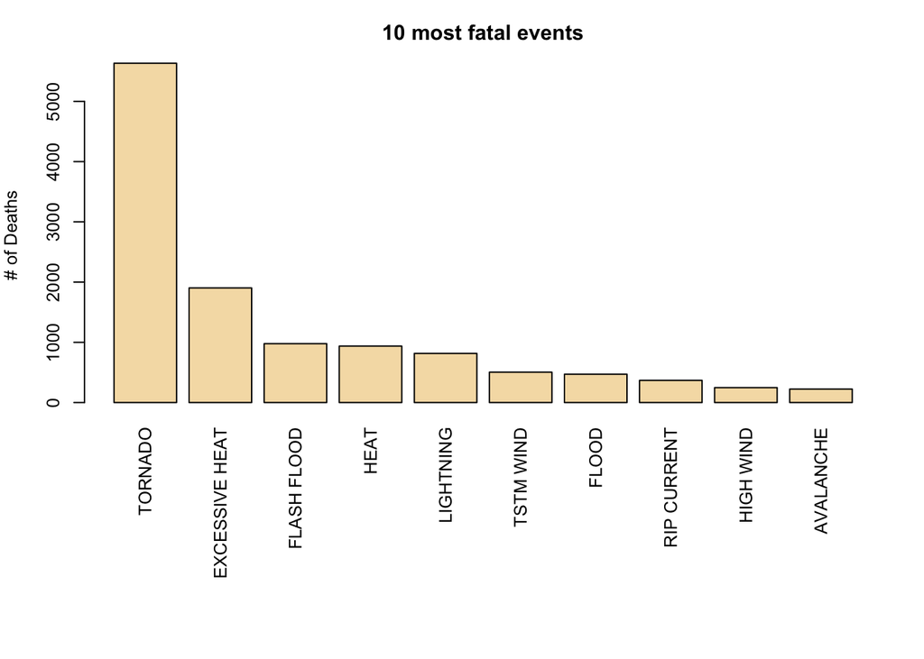

```r
par(mfrow = c(1,1), mar = c(12, 4, 3, 2), mgp = c(3, 1, 0), cex = 0.8)
barplot(most_fatal_events$FATALITIES, names.arg = most_fatal_events$EVTYPE,las = 3,col="wheat",main="10 most fatal events",ylab="# of Deaths")
```

```r
dev.copy(png, "fatal-events.png", width = 480, height = 480)
```

```r
dev.off()
```

```r
most_injuries_events<-head(total_injuries_sorted,10)
most_injuries_events
```

```
##               EVTYPE INJURIES
## 1            TORNADO    91346
## 2          TSTM WIND     6957
## 3              FLOOD     6789
## 4     EXCESSIVE HEAT     6525
## 5          LIGHTNING     5230
## 6               HEAT     2100
## 7          ICE STORM     1975
## 8        FLASH FLOOD     1777
## 9  THUNDERSTORM WIND     1488
## 10              HAIL     1361
```

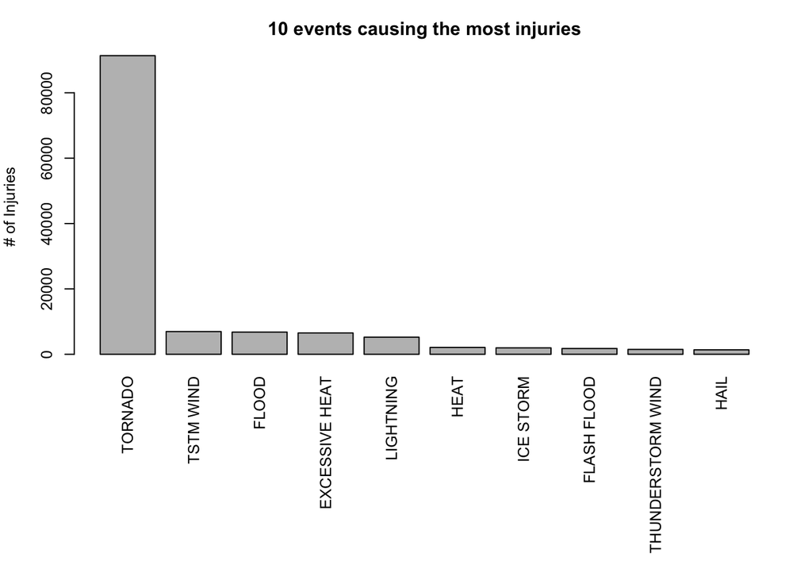

```r
par(mfrow = c(1,1), mar = c(12, 4, 3, 2), mgp = c(3, 1, 0), cex = 0.8)
barplot(most_injuries_events$INJURIES, names.arg = most_injuries_events$EVTYPE,las = 3,col="grey", main="10 events causing the most injuries",ylab="# of Injuries")
```

```r
dev.copy(png, "injuries-events.png", width = 480, height = 480)
```

```r
dev.off()
```

### 2. Across the United States, which types of events have the greatest economic consequences?

```r
# For this question I am going to find which EVTYPE lead to more property and crop damage (PROPDMGTOTAL,CROPDMGTOTAL) and present the 10 most fatal ones

#first I need to create a total variable for property and crop damage
# PROPDMGTOTAL=PROPDMG+PROPDMGEXP
storm$PROPDMGEXP <- mapvalues(storm$PROPDMGEXP, from = c("K", "M","", "B", "m", "+", "0", "5", "6", "?", "4", "2", "3", "h", "7", "H", "-", "1", "8"), to = c(10^3, 10^6, 1, 10^9, 10^6, 0,1,10^5, 10^6, 0, 10^4, 10^2, 10^3, 10^2, 10^7, 10^2, 0, 10, 10^8))
storm$PROPDMGEXP <- as.numeric(as.character(storm$PROPDMGEXP))
storm$PROPDMGTOTAL <- (storm$PROPDMG * storm$PROPDMGEXP)/1000000000

prop_damage<-aggregate(PROPDMGTOTAL ~ EVTYPE, data=storm, FUN = sum)

#CROPDMGTOTAL=CROPDMG+CROPDMGEXP
storm$CROPDMGEXP <- mapvalues(storm$CROPDMGEXP, from = c("","M", "K", "m", "B", "?", "0", "k","2"), to = c(1,10^6, 10^3, 10^6, 10^9, 0, 1, 10^3, 10^2))
storm$CROPDMGEXP <- as.numeric(as.character(storm$CROPDMGEXP))
storm$CROPDMGTOTAL <- (storm$CROPDMG * storm$CROPDMGEXP)/1000000000

crop_damage<-aggregate(CROPDMGTOTAL ~ EVTYPE, data=storm, FUN = sum)

total_prop_damage<- prop_damage %>% arrange(-prop_damage$PROPDMGTOTAL)

total_crop_damage<- crop_damage %>% arrange(-crop_damage$CROPDMGTOTAL)

most_prop_damage_events<-head(total_prop_damage,10)
most_prop_damage_events
```

```
##               EVTYPE PROPDMGTOTAL
## 1              FLOOD   144.657710
## 2  HURRICANE/TYPHOON    69.305840
## 3            TORNADO    56.947381
## 4        STORM SURGE    43.323536
## 5        FLASH FLOOD    16.822674
## 6               HAIL    15.735268
## 7          HURRICANE    11.868319
## 8     TROPICAL STORM     7.703891
## 9       WINTER STORM     6.688497
## 10         HIGH WIND     5.270046
```

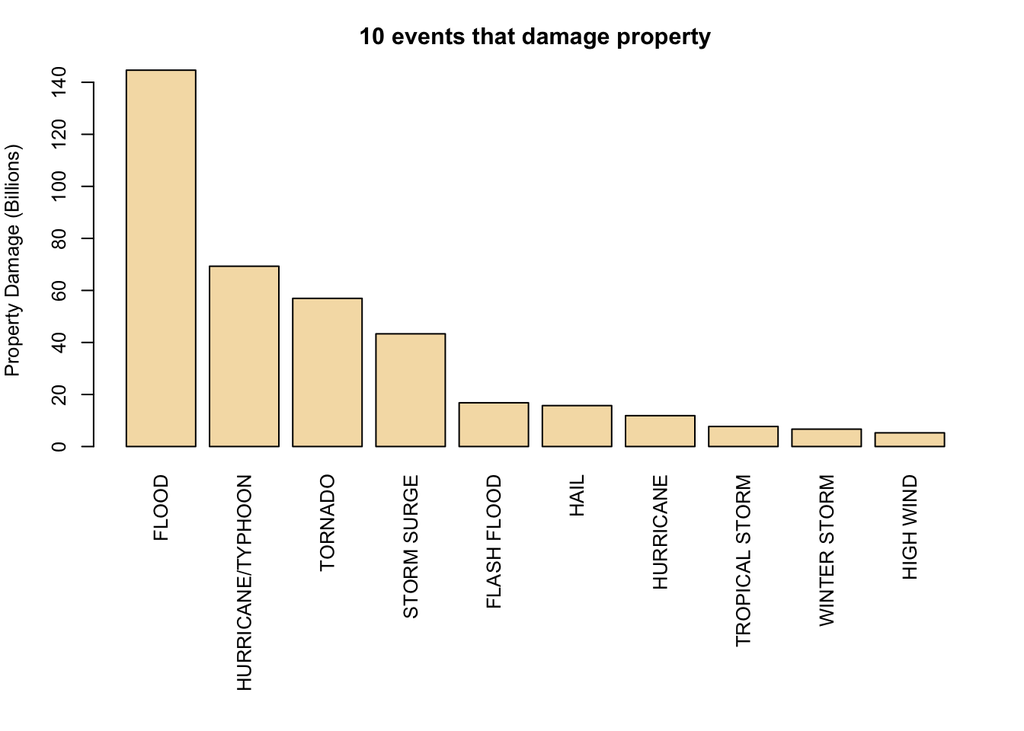

```r
par(mfrow = c(1,1), mar = c(12, 4, 3, 2), mgp = c(3, 1, 0), cex = 0.8)
barplot(most_prop_damage_events$PROPDMGTOTAL, names.arg = most_prop_damage_events$EVTYPE,las = 3,col="wheat",main="10 events that damage property",ylab="Property Damage (Billions)")
```

```r
dev.copy(png, "prop_damage.png", width = 480, height = 480)
```

```r
dev.off()
```

```r
most_crop_damage_events<-head(total_crop_damage,10)
most_crop_damage_events
```

```
##               EVTYPE CROPDMGTOTAL
## 1            DROUGHT    13.972566
## 2              FLOOD     5.661968
## 3        RIVER FLOOD     5.029459
## 4          ICE STORM     5.022113
## 5               HAIL     3.025954
## 6          HURRICANE     2.741910
## 7  HURRICANE/TYPHOON     2.607873
## 8        FLASH FLOOD     1.421317
## 9       EXTREME COLD     1.292973
## 10      FROST/FREEZE     1.094086
```

[figure not shown]

```r
par(mfrow = c(1,1), mar = c(12, 4, 3, 2), mgp = c(3, 1, 0), cex = 0.8)
barplot(most_crop_damage_events$CROPDMGTOTAL, names.arg = most_crop_damage_events$EVTYPE,las = 3,col="grey", main="10 events causing the most injuries",ylab="10 events that damage crops (Billions)")
```

```r
dev.copy(png, "crop_damage.png", width = 480, height = 480)
```

```r
dev.off()
```

# Results

### 1. Across the United States, which types of events (as indicated in the EVTYPE variable) are most harmful with respect to population health?

The analysis and graphs indicate the most harmful type of weather phenomena with respect to death are *Tornados* Excessive Heat *Flash Flood while in terms of injuries are* Tornados *TSTM Wind* Flood

### 2. Across the United States, which types of events have the greatest economic consequences?

The most harmful events in terms of property damage are *Flood* Hurricanes/Typhoons *Tornados while in terms of crop damage are* Drought *Flood* River Flood